# Time Series Model for University of Michigan Inflation Expectation Using Python and ARIMA

### October 28, 2020

Template Credit: Adapted from a template made available by Dr. Jason Brownlee of Machine Learning Mastery. https://machinelearningmastery.com/

SUMMARY: The purpose of this project is to construct a time series prediction model and document the end-to-end steps using a template. The Inflation Expectation dataset from University of Michigan is a time series situation where we are trying to forecast future outcomes based on past data points.

INTRODUCTION: The problem is forecasting the monthly number of median expected price change next 12 months based on surveys of consumers. The dataset describes a time-series of percentages over 42 years (1978-2020), and there are 512 observations. We used the first 80% of the observations for training various models while holding back the remaining observations for validating the final model.

ANALYSIS: The baseline prediction (or persistence) for the dataset resulted in an RMSE of 0.221. After performing a grid search for the most optimal ARIMA parameters, the final ARIMA non-seasonal order was (4, 1, 2). Furthermore, the chosen model processed the validation data with an RMSE of 0.206, which was better than the baseline model as expected.

CONCLUSION: For this dataset, the chosen ARIMA model achieved a satisfactory result and should be considered for further modeling.

Dataset Used: University of Michigan: Inflation Expectation

Dataset ML Model: Time series forecast with numerical attribute

Dataset Reference: University of Michigan, University of Michigan: Inflation Expectation [MICH], retrieved from FRED, Federal Reserve Bank of St. Louis; https://fred.stlouisfed.org/series/MICH, October 24, 2020.

A time series predictive modeling project generally can be broken down into about five major tasks:

1. Define Problem and Acquire Data
2. Inspect and Explore Data
3. Clean and Pre-Process Data
4. Fit and Evaluate Models
5. Finalize Model and Make Predictions

## Task 1: Define Problem and Acquire Data

```python
# Install the necessary packages for Colab
# !pip install python-dotenv PyMySQL
```

```python
# Retrieve the GPU information from Colab
# gpu_info = !nvidia-smi
# gpu_info = '\n'.join(gpu_info)
# if gpu_info.find('failed') >= 0:
#     print('Select the Runtime → "Change runtime type" menu to enable a GPU accelerator, ')
#     print('and then re-execute this cell.')
# else:
#     print(gpu_info)
```

```python
# Retrieve the memory configuration from Colab
# from psutil import virtual_memory
# ram_gb = virtual_memory().total / 1e9
# print('Your runtime has {:.1f} gigabytes of available RAM\n'.format(ram_gb))

# if ram_gb < 20:
#     print('To enable a high-RAM runtime, select the Runtime → "Change runtime type"')
#     print('menu, and then select High-RAM in the Runtime shape dropdown. Then, ')
#     print('re-execute this cell.')
# else:
#     print('You are using a high-RAM runtime!')
```

```python
# Retrieve the CPU information
ncpu = !nproc
print("The number of available CPUs is:", ncpu[0])
```

```
The number of available CPUs is: 4
```

### 1.a) Load Libraries

```python
# Create the random seed number for reproducible results
seedNum = 888
```

```python
import pandas as pd
import matplotlib.pyplot as plt
import seaborn as sns
import pmdarima as pm
import os
import sys
import math
import boto3
from datetime import datetime
from sklearn.metrics import mean_squared_error
from statsmodels.tsa.statespace.sarimax import SARIMAX
from statsmodels.tsa.stattools import adfuller
from statsmodels.tsa.seasonal import seasonal_decompose
from statsmodels.graphics.tsaplots import plot_acf
from statsmodels.graphics.tsaplots import plot_pacf
import pandas_datareader.data as web
```

### 1.b) Set up the controlling parameters and functions

```python
# Begin the timer for the script processing
startTimeScript = datetime.now()

# Set up the number of CPU cores available for multi-thread processing
n_jobs = 1

# Set up the flag to stop sending progress emails (setting to True will send status emails!)
notifyStatus = False

# Set up the parent directory location for loading the dotenv files
useGDrive = False
if useGDrive:
    # Mount Google Drive locally for storing files
    from google.colab import drive
    drive.mount('/content/gdrive')
    gdrivePrefix = '/content/gdrive/My Drive/Colab_Downloads/'
    env_path = '/content/gdrive/My Drive/Colab Notebooks/'
    dotenv_path = env_path + "python_script.env"
    load_dotenv(dotenv_path=dotenv_path)

# Set up the dotenv file for retrieving environment variables
useLocalPC = False
if useLocalPC:
    env_path = "/Users/david/PycharmProjects/"
    dotenv_path = env_path + "python_script.env"
    load_dotenv(dotenv_path=dotenv_path)

# Configure the plotting style
plt.style.use('seaborn')

# Set Pandas options
pd.set_option("display.max_rows", 500)
pd.set_option("display.width", 140)
```

```python
# Set up the email notification function
def status_notify(msg_text):
    access_key = os.environ.get('SNS_ACCESS_KEY')
    secret_key = os.environ.get('SNS_SECRET_KEY')
    aws_region = os.environ.get('SNS_AWS_REGION')
    topic_arn = os.environ.get('SNS_TOPIC_ARN')
    if (access_key is None) or (secret_key is None) or (aws_region is None):
        sys.exit("Incomplete notification setup info. Script Processing Aborted!!!")
    sns = boto3.client('sns', aws_access_key_id=access_key, aws_secret_access_key=secret_key, region_name=aws_region)
    response = sns.publish(TopicArn=topic_arn, Message=msg_text)
    if response['ResponseMetadata']['HTTPStatusCode'] != 200 :
        print('Status notification not OK with HTTP status code:', response['ResponseMetadata']['HTTPStatusCode'])
```

```python
if notifyStatus: status_notify("ARIMA Task 1: Define Problem and Acquire Data has begun! "+datetime.now().strftime('%a %B %d, %Y %I:%M:%S %p'))
```

### 1.c) Acquire and Load the Data

```python
# load the dataset and the necessary data structure
# time_series = pd.read_csv('https://dainesanalytics.com/datasets/time-series-data-library/tsdl200.csv', index_col='idx', parse_dates=True)

# Load the dataset from the Federal Reserve Bank's FRED Database
starting = datetime(1978, 1, 1)
ending = datetime.now()
fred_data = 'MICH'
time_series = web.DataReader(fred_data, 'fred', starting, ending)
time_series.rename(columns={fred_data: 'value'}, inplace=True)

# Sample code for subsetting the time-series data
# time_series = original_series['1986':'2020']
```

```python
target_col = time_series.columns[0]
lower_bound = 'lower ' + target_col
upper_bound = 'upper ' + target_col
print('The target column of the time series is:', target_col)
print('The forecast boundary columns are:', lower_bound, '&', upper_bound)
```

```
The target column of the time series is: value
The forecast boundary columns are: lower value & upper value
```

```python
time_series.info(verbose=True)
```

```
<class 'pandas.core.frame.DataFrame'>
DatetimeIndex: 512 entries, 1978-01-01 to 2020-08-01
Data columns (total 1 columns):
 #   Column  Non-Null Count  Dtype
---  ------  --------------  -----
 0   value   512 non-null    float64
dtypes: float64(1)
memory usage: 8.0 KB
```

```python
time_series.head(10)
```

| DATE | value |
| --- | --- |
| 1978-01-01 | 5.2 |
| 1978-02-01 | 6.4 |
| 1978-03-01 | 6.3 |
| 1978-04-01 | 6.7 |
| 1978-05-01 | 6.9 |
| 1978-06-01 | 6.5 |
| 1978-07-01 | 6.6 |
| 1978-08-01 | 8.7 |
| 1978-09-01 | 6.9 |
| 1978-10-01 | 7.4 |

```python
time_series.tail(10)
```

| DATE | value |
| --- | --- |
| 2019-11-01 | 2.5 |
| 2019-12-01 | 2.3 |
| 2020-01-01 | 2.5 |
| 2020-02-01 | 2.4 |
| 2020-03-01 | 2.2 |
| 2020-04-01 | 2.1 |
| 2020-05-01 | 3.2 |
| 2020-06-01 | 3.0 |
| 2020-07-01 | 3.0 |
| 2020-08-01 | 3.1 |

```python
if notifyStatus: status_notify("ARIMA Task 1: Define Problem and Acquire Data completed! "+datetime.now().strftime('%a %B %d, %Y %I:%M:%S %p'))
```

## Task 2: Inspect and Explore Data

```python
if notifyStatus: status_notify("ARIMA Task 2: Inspect and Explore Data has begun! "+datetime.now().strftime('%a %B %d, %Y %I:%M:%S %p'))
```

### 2.a) Summary Statistics of the Time Series Data

Summary statistics provide a quick look at the limits of observed values. It can help to get a quick idea of what we are working with.

```python
# Summary statistics of time series
print(time_series.describe())
```

```
            value
count  512.000000
mean     3.550586
std      1.668975
min      0.400000
25%      2.800000
50%      3.000000
75%      3.400000
max     10.400000
```

### 2.b) Line Plot of the Time Series Data

A line plot of a time series can provide a lot of insight into the problem. Some observations from the plot can include:

- Whether the trend appears to be level around the mean
- Whether there appear to be any obvious outliers

The ARIMA(p,d,q) model requires three parameters and assumes that we are working with a stationary time series.

The ADF results should show that the test statistic value is smaller than the critical value at 5% if the time series is stationary. This suggests that we can reject the null hypothesis (i.e. a low probability that the result is a statistical fluke).

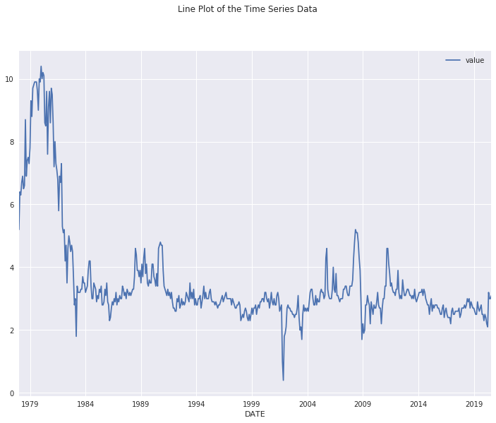

```python
# Line plots of time series
fig, ax = plt.subplots(figsize=(12,9))
fig.suptitle('Line Plot of the Time Series Data')
time_series.plot(ax=ax)
plt.show()
```

### 2.c) Histogram and Density Plots of the Time Series Data

Reviewing plots of the density of observations can provide further insight into the structure of the data. Some observations from the plots can include:

- Whether the distribution is Gaussian
- Whether the distribution has a long tail and may suggest the need for data transformation

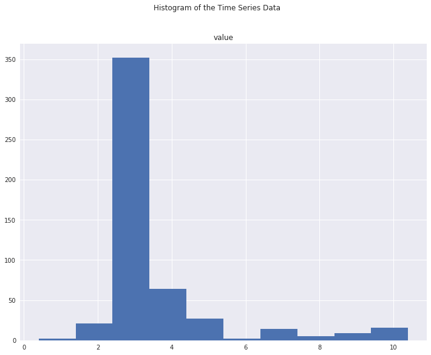

```python
# Line plots of time series
fig, ax = plt.subplots(figsize=(12,9))
fig.suptitle('Histogram of the Time Series Data')
time_series.hist(ax=ax)
plt.show()
```

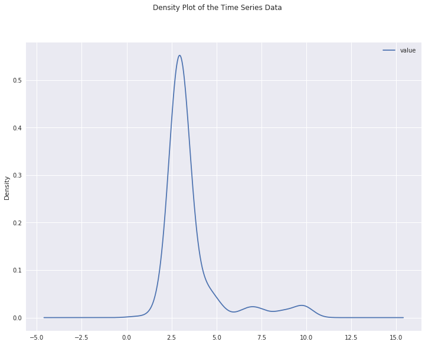

```python
# Line plots of time series
fig, ax = plt.subplots(figsize=(12,9))
fig.suptitle('Density Plot of the Time Series Data')
time_series.plot(kind='kde', ax=ax)
plt.show()
```

### 2.d) Box and Whisker Plots of the Time Series Data

We can group or aggregate the data and get a better idea of the spread of observations. Some observations from reviewing the plot can include:

- Whether the median values for each grouping shows any significant trend
- Whether the spread, or middle 50% of the data, shows any significant variability
- Whether there are outliers in some grouping

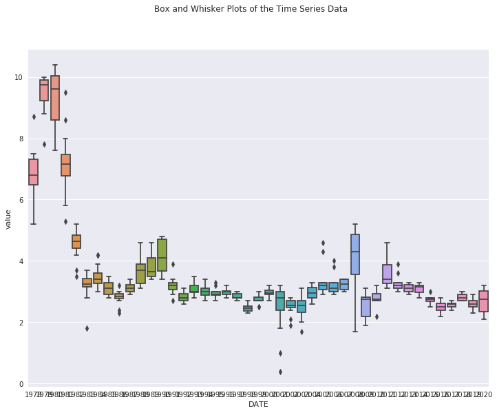

```python
# boxplots of time series
fig, ax = plt.subplots(figsize=(12,9))
fig.suptitle('Box and Whisker Plots of the Time Series Data')
squeezed = time_series.squeeze()
sns.boxplot(squeezed.index.year, squeezed, ax=ax)
plt.show()
```

```python
if notifyStatus: status_notify("ARIMA Task 2: Inspect and Explore Data completed! "+datetime.now().strftime('%a %B %d, %Y %I:%M:%S %p'))
```

## Task 3: Clean and Pre-Process Data

```python
if notifyStatus: status_notify("ARIMA Task 3: Clean and Pre-Process Data has begun! "+datetime.now().strftime('%a %B %d, %Y %I:%M:%S %p'))
```

### Section 3.a) Data Transformation

```python
# Resampling the time series into monthly average for the ease of modeling
# original_series = time_series
# resample = original_series.resample('M')
# time_series = resample.mean()
# time_series.head(10)
```

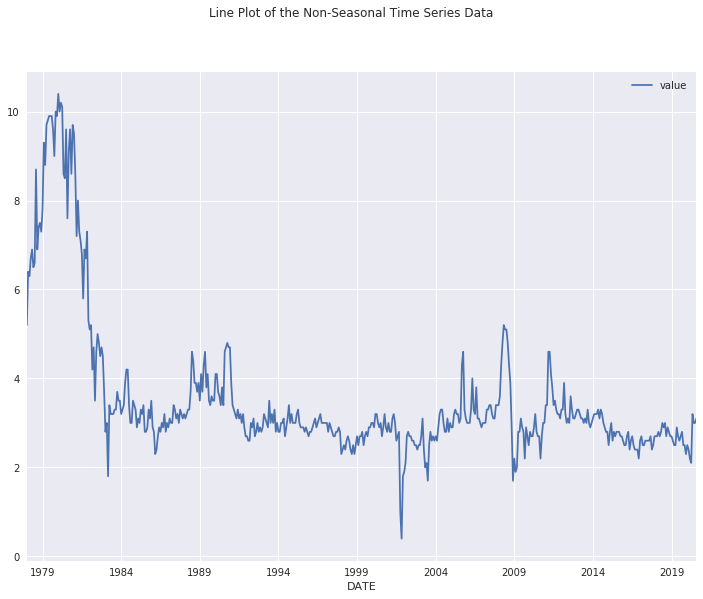

```python
# Line plots of the transformed time series
fig, ax = plt.subplots(figsize=(12,9))
fig.suptitle('Line Plot of the Non-Seasonal Time Series Data')
time_series.plot(ax=ax)
plt.show()
```

### Section 3.b) Test for Stationarity

```python
# Check if stationary
result = adfuller(time_series[target_col])
print('ADF Statistic: %f' % result[0])
print('p-value: %f' % result[1])
print('Critical Test Statistics Values:')
for key, value in result[4].items():
    print('\t%s: %.3f' % (key, value))
```

```
ADF Statistic: -4.875418
p-value: 0.000039
Critical Test Statistics Values:
	1%: -3.444
	5%: -2.867
	10%: -2.570
```

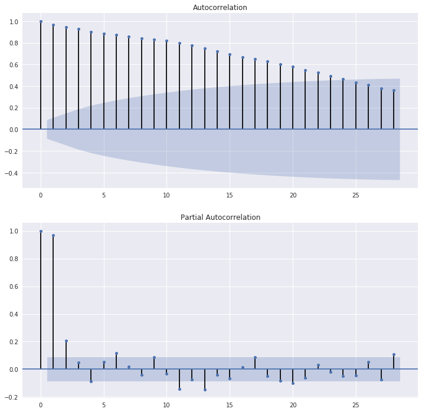

```python
# ACF and PACF plots of the time series data
fig, (ax1, ax2) = plt.subplots(2, 1, figsize=(12,12))
plot_acf(time_series, ax=ax1)
plot_pacf(time_series, ax=ax2)
plt.show()
```

### 3.c) Test for Stationarity of Non-Seasonal Time Series Data

Occasionally a time series may look non-stationary on the first look. We can make it stationary by differencing the series and using a statistical test to confirm that the differenced result is stationary. Rejecting the null hypothesis means that the process has no unit root, and in turn that the time series is stationary or does not have time-dependent structure.

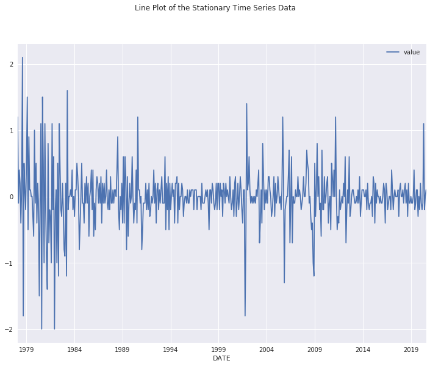

```python
# Create a differenced series
stationary_ns = time_series.diff().dropna()

# Plot differenced data
fig, ax = plt.subplots(figsize=(12,9))
fig.suptitle('Line Plot of the Stationary Time Series Data')
stationary_ns.plot(ax=ax)
plt.show()
```

```python
# Check for stationarity
result = adfuller(stationary_ns[target_col])
print('ADF Statistic: %f' % result[0])
print('p-value: %f' % result[1])
print('Critical Test Statistics Values:')
for key, value in result[4].items():
    print('\t%s: %.3f' % (key, value))
```

```
ADF Statistic: -5.813143
p-value: 0.000000
Critical Test Statistics Values:
	1%: -3.444
	5%: -2.867
	10%: -2.570
```

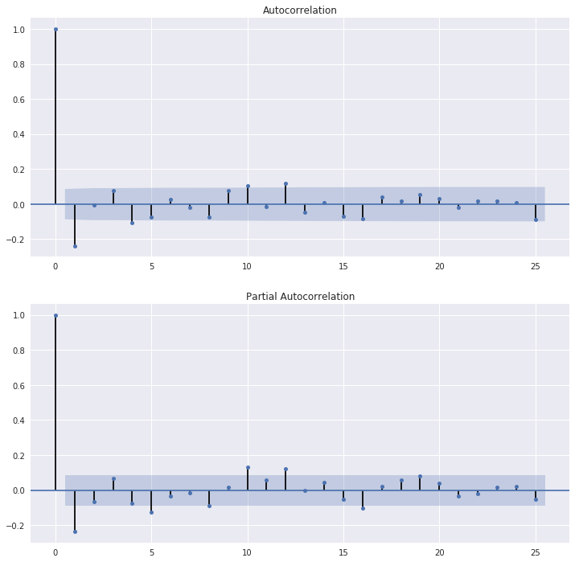

```python
# ACF and PACF plots of the stationary time series
lags = 25
fig, (ax1, ax2) = plt.subplots(2, 1, figsize=(12,12))
plot_acf(stationary_ns, lags=lags, ax=ax1)
plot_pacf(stationary_ns, lags=lags, ax=ax2)
plt.show()
```

### 3.d) Seasonal Decomposition for Seasonal Time Series Data

```python
# Set the initial seasonal frequency parameter
seasonal_freq = 0
```

```python
# # Perform seasonal decomposition to observe the seasonal frequency
# decomp_results = seasonal_decompose(time_series, period=seasonal_freq)
# decomp_results.plot()
# plt.show()
```

```python
# # Create a seasonal series
# N = seasonal_freq
# seasonal_series = time_series - time_series.rolling(N).mean()
# seasonal_series = seasonal_series.dropna()

# # Line plots of the seasonal time series
# fig, ax = plt.subplots(figsize=(12,9))
# fig.suptitle('Line Plot of the Seasonal Time Series Data')
# seasonal_series.plot(ax=ax)
# plt.show()
```

```python
# # Check for stationarity
# result = adfuller(seasonal_series[target_col])
# print('ADF Statistic: %f' % result[0])
# print('p-value: %f' % result[1])
# print('Critical Test Statistics Values:')
# for key, value in result[4].items():
#     print('\t%s: %.3f' % (key, value))
```

```python
# # ACF and PACF plots of the time series data
# lag = seasonal_freq * 2
# fig, (ax1, ax2) = plt.subplots(2, 1, figsize=(12,12))
# plot_acf(seasonal_series, lags=lag, ax=ax1)
# plot_pacf(seasonal_series, lags=lag, ax=ax2)
# plt.show()
```

### 3.e) Test for Stationarity of Seasonal Time Series Data

Occasionally a time series may look non-stationary on the first look. We can make it stationary by differencing the series and using a statistical test to confirm that the differenced result is stationary. Rejecting the null hypothesis means that the process has no unit root, and in turn that the time series is stationary or does not have time-dependent structure.

```python
# # Create a differenced series
# stationary_ss = time_series.diff(seasonal_freq).dropna()

# # Plot differenced data
# fig, ax = plt.subplots(figsize=(12,9))
# fig.suptitle('Line Plot of the Stationary Seasonal Time Series Data')
# stationary_ss.plot(ax=ax)
# plt.show()
```

```python
# # Check for stationarity
# result = adfuller(stationary_ss[target_col])
# print('ADF Statistic: %f' % result[0])
# print('p-value: %f' % result[1])
# print('Critical Test Statistics Values:')
# for key, value in result[4].items():
#     print('\t%s: %.3f' % (key, value))
```

```python
# # ACF and PACF plots of the stationary time series
# lags = seasonal_freq * 2
# fig, (ax1, ax2) = plt.subplots(2, 1, figsize=(12,12))
# plot_acf(stationary_ss, lags=lags, ax=ax1)
# plot_pacf(stationary_ss, lags=lags, ax=ax2)
# plt.show()
```

```python
if notifyStatus: status_notify("ARIMA Task 3: Clean and Pre-Process Data completed! "+datetime.now().strftime('%a %B %d, %Y %I:%M:%S %p'))
```

## Task 4: Fit and Evaluate Models

```python
if notifyStatus: status_notify("ARIMA Task 4: Fit and Evaluate Models has begun! "+datetime.now().strftime('%a %B %d, %Y %I:%M:%S %p'))
```

### 4.a) Establish the Persistent Model

The first step before getting bogged down in data analysis and modeling is to establish a baseline of performance. This will provide both a template for evaluating models using the proposed test harness and a performance measure by which all more elaborate predictive models can be compared.

The baseline prediction for time series forecasting is called the naive forecast, or persistence. This is where the observation from the previous time step is used as the prediction for the observation at the next time step.

#### 4.a.iii) Establish the Persistent Model as Baseline

```python
# Prepare and evaluate a persistence model
X = time_series.values
X = X.astype('float32')
train_pct = 0.80
train_size = int(len(X) * train_pct)
test_size = len(X) - train_size
train_ts, test_ts = X[0:train_size], X[train_size:]

# walk-forward validation
history = [x for x in train_ts]
predictions = list()
for i in range(len(test_ts)):
    yhat = history[-1]
    predictions.append(yhat)
    obs = test_ts[i]
    history.append(obs)
    print('>Predicted=%.3f, Expected=%3.f' % (yhat, obs))

# Calculate performance
rmse = math.sqrt(mean_squared_error(test_ts, predictions))
print('RMSE for the persistent model is: %.3f' % rmse)
```

```
>Predicted=3.300, Expected=  3
>Predicted=3.300, Expected=  4
>Predicted=3.900, Expected=  3
>Predicted=3.200, Expected=  3
>Predicted=3.000, Expected=  3
>Predicted=3.100, Expected=  3
>Predicted=3.000, Expected=  4
>Predicted=3.600, Expected=  3
>Predicted=3.300, Expected=  3
>Predicted=3.100, Expected=  3
>Predicted=3.100, Expected=  3
>Predicted=3.200, Expected=  3
>Predicted=3.300, Expected=  3
>Predicted=3.300, Expected=  3
>Predicted=3.200, Expected=  3
>Predicted=3.100, Expected=  3
>Predicted=3.100, Expected=  3
>Predicted=3.000, Expected=  3
>Predicted=3.100, Expected=  3
>Predicted=3.000, Expected=  3
>Predicted=3.300, Expected=  3
>Predicted=3.000, Expected=  3
>Predicted=2.900, Expected=  3
>Predicted=3.000, Expected=  3
>Predicted=3.100, Expected=  3
>Predicted=3.200, Expected=  3
>Predicted=3.200, Expected=  3
>Predicted=3.200, Expected=  3
>Predicted=3.300, Expected=  3
>Predicted=3.100, Expected=  3
>Predicted=3.300, Expected=  3
>Predicted=3.200, Expected=  3
>Predicted=3.000, Expected=  3
>Predicted=2.900, Expected=  3
>Predicted=2.800, Expected=  3
>Predicted=2.800, Expected=  2
>Predicted=2.500, Expected=  3
>Predicted=2.800, Expected=  3
>Predicted=3.000, Expected=  3
>Predicted=2.600, Expected=  3
```

[output cut: 49 more lines]

```
>Predicted=2.700, Expected=  3
>Predicted=2.600, Expected=  3
>Predicted=2.700, Expected=  3
>Predicted=2.800, Expected=  2
>Predicted=2.500, Expected=  2
>Predicted=2.500, Expected=  2
>Predicted=2.300, Expected=  2
>Predicted=2.500, Expected=  2
>Predicted=2.400, Expected=  2
>Predicted=2.200, Expected=  2
>Predicted=2.100, Expected=  3
>Predicted=3.200, Expected=  3
>Predicted=3.000, Expected=  3
>Predicted=3.000, Expected=  3
RMSE for the persistent model is: 0.221
```

### 4.b) Grid Search of ARIMA Hyperparameters

We want to find a model that can do better than the persistence model on this dataset. To confirm this analysis, we can grid search a suite of ARIMA hyperparameters.

In this section, we will search values of p, d, and q for combinations (skipping those that fail to converge), and find the combination that results in the best performance. We will use a grid search to explore all combinations in a subset of integer values.

```python
if notifyStatus: status_notify("ARIMA Hyperparameters Search has begun! "+datetime.now().strftime('%a %B %d, %Y %I:%M:%S %p'))
```

```python
# Set the initial P, D, and Q order parameters for non-seasonal ARIMA modeling
start_p = 0
start_q = 0
max_p = 4
max_d = 2
max_q = 4
```

```python
# Set the initial P, D, and Q order parameters for seasonal ARIMA modeling
start_P = 0
start_D = None
start_Q = 0
max_P = 2
max_D = 1
max_Q = 2
```

```python
# Testing the time series data for suggestions on the differencing term
start_d = pm.arima.ndiffs(train_ts)
print('The suggested non-seasonal differencing term is:', start_d)
if seasonal_freq != 0:
    start_D = pm.arima.nsdiffs(train_ts, m = seasonal_freq)
    print('The suggested seasonal differencing term is:', start_D)
```

```
The suggested non-seasonal differencing term is: 1
```

```python
print('The initial non-seasonal parameters are: p =', start_p, '| d =', start_d, '| q =', start_q)
print('The maximum non-seasonal parameters are: max_p =', max_p, '| max_d =', max_d, '| max_q =', max_q)
if seasonal_freq != 0:
    print('The initial seasonal parameters are: P =', start_P, '| D =', start_D, '| Q =', start_Q, '| m =', seasonal_freq)
    print('The maximum seasonal parameters are: max_P =', max_P, '| max_D =', max_D, '| max_Q =', max_Q)
```

```
The initial non-seasonal parameters are: p = 0 | d = 1 | q = 0
The maximum non-seasonal parameters are: max_p = 4 | max_d = 2 | max_q = 4
```

```python
# Do an automated stepwise search of ARIMA parameters
if seasonal_freq == 0:
    stepwise_results = pm.auto_arima(train_ts, seasonal = False, stepwise = True, trace = True, suppress_warnings = True, random_state = seedNum)
else:
    stepwise_results = pm.auto_arima(train_ts, seasonal = True, m = seasonal_freq, stepwise = True, trace = True, suppress_warnings = True, random_state = seedNum)
```

```
Performing stepwise search to minimize aic
 ARIMA(2,1,2)(0,0,0)[0] intercept   : AIC=508.499, Time=1.34 sec
 ARIMA(0,1,0)(0,0,0)[0] intercept   : AIC=532.757, Time=0.28 sec
 ARIMA(1,1,0)(0,0,0)[0] intercept   : AIC=511.692, Time=0.24 sec
 ARIMA(0,1,1)(0,0,0)[0] intercept   : AIC=510.938, Time=0.25 sec
 ARIMA(0,1,0)(0,0,0)[0]             : AIC=530.799, Time=0.06 sec
 ARIMA(1,1,2)(0,0,0)[0] intercept   : AIC=514.728, Time=0.87 sec
 ARIMA(2,1,1)(0,0,0)[0] intercept   : AIC=512.615, Time=1.71 sec
 ARIMA(3,1,2)(0,0,0)[0] intercept   : AIC=509.756, Time=2.32 sec
 ARIMA(2,1,3)(0,0,0)[0] intercept   : AIC=509.483, Time=1.90 sec
 ARIMA(1,1,1)(0,0,0)[0] intercept   : AIC=512.793, Time=0.42 sec
 ARIMA(1,1,3)(0,0,0)[0] intercept   : AIC=514.992, Time=1.55 sec
 ARIMA(3,1,1)(0,0,0)[0] intercept   : AIC=513.494, Time=0.95 sec
 ARIMA(3,1,3)(0,0,0)[0] intercept   : AIC=507.548, Time=2.73 sec
 ARIMA(4,1,3)(0,0,0)[0] intercept   : AIC=inf, Time=3.54 sec
 ARIMA(3,1,4)(0,0,0)[0] intercept   : AIC=509.153, Time=3.07 sec
 ARIMA(2,1,4)(0,0,0)[0] intercept   : AIC=510.647, Time=1.46 sec
 ARIMA(4,1,2)(0,0,0)[0] intercept   : AIC=499.541, Time=2.95 sec
 ARIMA(4,1,1)(0,0,0)[0] intercept   : AIC=508.096, Time=1.18 sec
 ARIMA(5,1,2)(0,0,0)[0] intercept   : AIC=509.529, Time=2.02 sec
 ARIMA(5,1,1)(0,0,0)[0] intercept   : AIC=507.611, Time=2.21 sec
 ARIMA(5,1,3)(0,0,0)[0] intercept   : AIC=510.621, Time=3.69 sec
 ARIMA(4,1,2)(0,0,0)[0]             : AIC=497.765, Time=1.41 sec
 ARIMA(3,1,2)(0,0,0)[0]             : AIC=507.830, Time=1.07 sec
 ARIMA(4,1,1)(0,0,0)[0]             : AIC=506.283, Time=0.95 sec
 ARIMA(5,1,2)(0,0,0)[0]             : AIC=507.715, Time=0.92 sec
 ARIMA(4,1,3)(0,0,0)[0]             : AIC=inf, Time=3.17 sec
 ARIMA(3,1,1)(0,0,0)[0]             : AIC=511.577, Time=0.40 sec
 ARIMA(3,1,3)(0,0,0)[0]             : AIC=505.706, Time=1.96 sec
 ARIMA(5,1,1)(0,0,0)[0]             : AIC=505.795, Time=0.73 sec
 ARIMA(5,1,3)(0,0,0)[0]             : AIC=508.790, Time=1.96 sec

Best model:  ARIMA(4,1,2)(0,0,0)[0]
Total fit time: 47.392 seconds
```

```
                               SARIMAX Results
==============================================================================
Dep. Variable:                      y   No. Observations:                  409
Model:               SARIMAX(4, 1, 2)   Log Likelihood                -241.883
Date:                Sun, 25 Oct 2020   AIC                            497.765
Time:                        19:37:18   BIC                            525.844
Sample:                             0   HQIC                           508.876
                                - 409
Covariance Type:                  opg
==============================================================================
                 coef    std err          z      P>|z|      [0.025      0.975]
------------------------------------------------------------------------------
ar.L1          1.2077      0.078     15.514      0.000       1.055       1.360
ar.L2         -0.4986      0.079     -6.335      0.000      -0.653      -0.344
ar.L3         -0.1092      0.070     -1.554      0.120      -0.247       0.029
ar.L4         -0.1454      0.048     -3.058      0.002      -0.239      -0.052
ma.L1         -1.4969      0.073    -20.369      0.000      -1.641      -1.353
ma.L2          0.8491      0.070     12.190      0.000       0.713       0.986
sigma2         0.1914      0.008     23.703      0.000       0.176       0.207
===================================================================================
Ljung-Box (Q):                       48.29   Jarque-Bera (JB):               361.44
Prob(Q):                              0.17   Prob(JB):                         0.00
Heteroskedasticity (H):               0.55   Skew:                            -0.27
Prob(H) (two-sided):                  0.00   Kurtosis:                         7.58
===================================================================================

Warnings:
[1] Covariance matrix calculated using the outer product of gradients (complex-step).
```

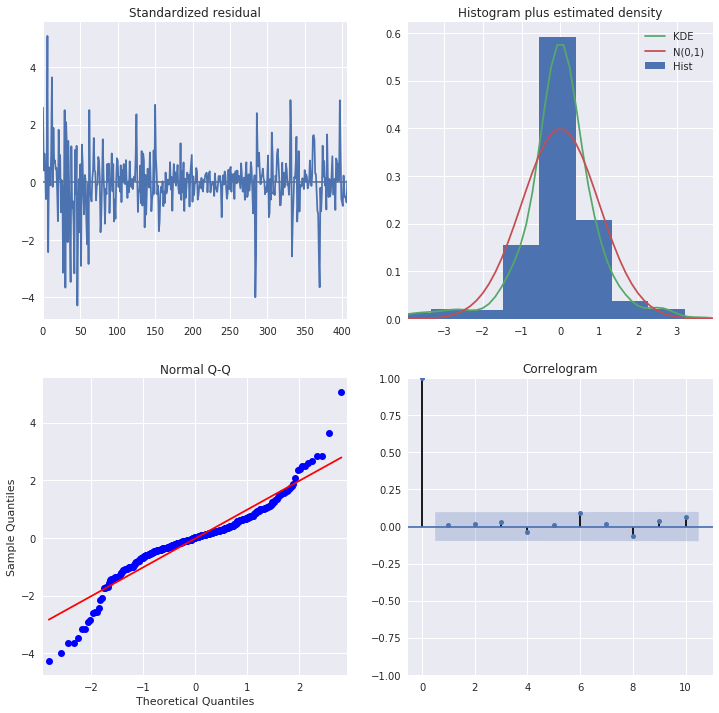

```python
# Summarize residual errors for the automated grid search ARIMA model
print(stepwise_results.summary())
stepwise_results.plot_diagnostics(figsize=(12,12))
plt.show()
```

```python
if notifyStatus: status_notify("ARIMA automated stepwise search completed! "+datetime.now().strftime('%a %B %d, %Y %I:%M:%S %p'))
```

```python
# Do an automated random search of ARIMA parameters
n_fits = int(max_p * max_d * max_q * max_P * max_D * max_Q * 0.30)
if seasonal_freq == 0:
    randgrid_results = pm.auto_arima(train_ts, start_p = start_p, d = start_d, start_q = start_q, max_p = max_p, max_d = max_d, max_q = max_q,
                                     seasonal = False, stepwise = False, random = True, n_fits = n_fits, max_order = None,
                                     trace = True, suppress_warnings = True, random_state = seedNum)
else:
    randgrid_results = pm.auto_arima(train_ts, start_p = start_p, d = start_d, start_q = start_q, max_p = max_p, max_d = max_d, max_q = max_q,
                                     seasonal = True, m = seasonal_freq, start_P = start_P, D = start_D, start_Q = start_Q, max_P = max_P, max_D = max_D, max_Q = max_Q,
                                     stepwise = False, random = True, n_fits = n_fits, max_order = None,
                                     trace = True, suppress_warnings = True, random_state = seedNum)
```

```
 ARIMA(1,1,0)(0,0,0)[0] intercept   : AIC=511.692, Time=0.24 sec
 ARIMA(2,1,0)(0,0,0)[0] intercept   : AIC=512.335, Time=0.31 sec
 ARIMA(4,1,1)(0,0,0)[0] intercept   : AIC=508.096, Time=1.14 sec
 ARIMA(0,1,1)(0,0,0)[0] intercept   : AIC=510.938, Time=0.25 sec
 ARIMA(0,1,4)(0,0,0)[0] intercept   : AIC=507.014, Time=0.62 sec
 ARIMA(1,1,3)(0,0,0)[0] intercept   : AIC=514.992, Time=1.52 sec
 ARIMA(4,1,0)(0,0,0)[0] intercept   : AIC=511.453, Time=0.50 sec
 ARIMA(0,1,2)(0,0,0)[0] intercept   : AIC=512.738, Time=0.42 sec
 ARIMA(2,1,1)(0,0,0)[0] intercept   : AIC=512.615, Time=1.64 sec
 ARIMA(1,1,1)(0,0,0)[0] intercept   : AIC=512.793, Time=0.46 sec
 ARIMA(4,1,3)(0,0,0)[0] intercept   : AIC=522.637, Time=3.55 sec
 ARIMA(0,1,3)(0,0,0)[0] intercept   : AIC=514.591, Time=1.15 sec
 ARIMA(1,1,4)(0,0,0)[0] intercept   : AIC=508.723, Time=1.26 sec
 ARIMA(0,1,0)(0,0,0)[0] intercept   : AIC=532.757, Time=0.20 sec
 ARIMA(2,1,2)(0,0,0)[0] intercept   : AIC=508.499, Time=1.30 sec
 ARIMA(3,1,3)(0,0,0)[0] intercept   : AIC=507.548, Time=2.80 sec
 ARIMA(3,1,1)(0,0,0)[0] intercept   : AIC=513.494, Time=0.96 sec
 ARIMA(3,1,2)(0,0,0)[0] intercept   : AIC=509.756, Time=2.30 sec
 ARIMA(4,1,4)(0,0,0)[0] intercept   : AIC=499.750, Time=3.66 sec
 ARIMA(2,1,4)(0,0,0)[0] intercept   : AIC=510.647, Time=1.56 sec
 ARIMA(1,1,2)(0,0,0)[0] intercept   : AIC=514.728, Time=0.95 sec
 ARIMA(3,1,4)(0,0,0)[0] intercept   : AIC=509.153, Time=3.04 sec
 ARIMA(4,1,2)(0,0,0)[0] intercept   : AIC=499.541, Time=2.95 sec
 ARIMA(3,1,0)(0,0,0)[0] intercept   : AIC=512.113, Time=0.44 sec
 ARIMA(2,1,3)(0,0,0)[0] intercept   : AIC=509.483, Time=1.84 sec
Total fit time: 35.102 seconds
```

```
                               SARIMAX Results
==============================================================================
Dep. Variable:                      y   No. Observations:                  409
Model:               SARIMAX(4, 1, 2)   Log Likelihood                -241.770
Date:                Sun, 25 Oct 2020   AIC                            499.541
Time:                        19:37:55   BIC                            531.631
Sample:                             0   HQIC                           512.239
                                - 409
Covariance Type:                  opg
==============================================================================
                 coef    std err          z      P>|z|      [0.025      0.975]
------------------------------------------------------------------------------
intercept     -0.0036      0.008     -0.441      0.659      -0.020       0.012
ar.L1          1.2073      0.078     15.439      0.000       1.054       1.361
ar.L2         -0.4981      0.079     -6.333      0.000      -0.652      -0.344
ar.L3         -0.1090      0.070     -1.554      0.120      -0.246       0.029
ar.L4         -0.1460      0.048     -3.049      0.002      -0.240      -0.052
ma.L1         -1.4972      0.074    -20.182      0.000      -1.643      -1.352
ma.L2          0.8490      0.070     12.204      0.000       0.713       0.985
sigma2         0.1913      0.008     23.705      0.000       0.175       0.207
===================================================================================
Ljung-Box (Q):                       48.33   Jarque-Bera (JB):               361.93
Prob(Q):                              0.17   Prob(JB):                         0.00
Heteroskedasticity (H):               0.55   Skew:                            -0.27
Prob(H) (two-sided):                  0.00   Kurtosis:                         7.58
===================================================================================

Warnings:
[1] Covariance matrix calculated using the outer product of gradients (complex-step).
```

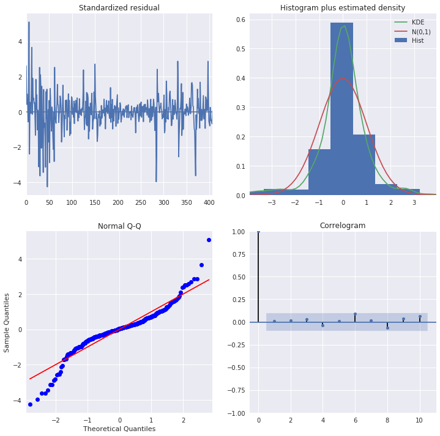

```python
# Summarize residual errors for the automated grid search ARIMA model
print(randgrid_results.summary())
randgrid_results.plot_diagnostics(figsize=(12,12))
plt.show()
```

```python
if notifyStatus: status_notify("ARIMA automated random search completed! "+datetime.now().strftime('%a %B %d, %Y %I:%M:%S %p'))
```

```python
# Do an automated grid search of ARIMA parameters
if (seasonal_freq == 0):
    autogrid_results = pm.auto_arima(train_ts, start_p = start_p, d = start_d, start_q = start_q, max_p = max_p, max_d = max_d, max_q = max_q,
                                     seasonal = False, stepwise = False, max_order = None, trace = True, suppress_warnings = True, random_state = seedNum)
else:
    autogrid_results = pm.auto_arima(train_ts, start_p = start_p, d = start_d, start_q = start_q, max_p = max_p, max_d = max_d, max_q = max_q,
                                     seasonal = True, m = seasonal_freq, start_P = start_P, D = start_D, start_Q = start_Q, max_P = max_P, max_D = max_D, max_Q = max_Q,
                                     stepwise = False, max_order = None, trace = True, suppress_warnings = True, random_state = seedNum)
```

```
 ARIMA(0,1,0)(0,0,0)[0] intercept   : AIC=532.757, Time=0.21 sec
 ARIMA(0,1,1)(0,0,0)[0] intercept   : AIC=510.938, Time=0.25 sec
 ARIMA(0,1,2)(0,0,0)[0] intercept   : AIC=512.738, Time=0.43 sec
 ARIMA(0,1,3)(0,0,0)[0] intercept   : AIC=514.591, Time=1.09 sec
 ARIMA(0,1,4)(0,0,0)[0] intercept   : AIC=507.014, Time=0.63 sec
 ARIMA(1,1,0)(0,0,0)[0] intercept   : AIC=511.692, Time=0.24 sec
 ARIMA(1,1,1)(0,0,0)[0] intercept   : AIC=512.793, Time=0.44 sec
 ARIMA(1,1,2)(0,0,0)[0] intercept   : AIC=514.728, Time=0.88 sec
 ARIMA(1,1,3)(0,0,0)[0] intercept   : AIC=514.992, Time=1.63 sec
 ARIMA(1,1,4)(0,0,0)[0] intercept   : AIC=508.723, Time=1.25 sec
 ARIMA(2,1,0)(0,0,0)[0] intercept   : AIC=512.335, Time=0.30 sec
 ARIMA(2,1,1)(0,0,0)[0] intercept   : AIC=512.615, Time=1.63 sec
 ARIMA(2,1,2)(0,0,0)[0] intercept   : AIC=508.499, Time=1.33 sec
 ARIMA(2,1,3)(0,0,0)[0] intercept   : AIC=509.483, Time=1.89 sec
 ARIMA(2,1,4)(0,0,0)[0] intercept   : AIC=510.647, Time=1.47 sec
 ARIMA(3,1,0)(0,0,0)[0] intercept   : AIC=512.113, Time=0.45 sec
 ARIMA(3,1,1)(0,0,0)[0] intercept   : AIC=513.494, Time=0.93 sec
 ARIMA(3,1,2)(0,0,0)[0] intercept   : AIC=509.756, Time=2.25 sec
 ARIMA(3,1,3)(0,0,0)[0] intercept   : AIC=507.548, Time=2.69 sec
 ARIMA(3,1,4)(0,0,0)[0] intercept   : AIC=509.153, Time=3.06 sec
 ARIMA(4,1,0)(0,0,0)[0] intercept   : AIC=511.453, Time=0.50 sec
 ARIMA(4,1,1)(0,0,0)[0] intercept   : AIC=508.096, Time=1.16 sec
 ARIMA(4,1,2)(0,0,0)[0] intercept   : AIC=499.541, Time=2.97 sec
 ARIMA(4,1,3)(0,0,0)[0] intercept   : AIC=522.637, Time=3.52 sec
 ARIMA(4,1,4)(0,0,0)[0] intercept   : AIC=499.750, Time=3.69 sec
Total fit time: 34.919 seconds
```

```
                               SARIMAX Results
==============================================================================
Dep. Variable:                      y   No. Observations:                  409
Model:               SARIMAX(4, 1, 2)   Log Likelihood                -241.770
Date:                Sun, 25 Oct 2020   AIC                            499.541
Time:                        19:38:31   BIC                            531.631
Sample:                             0   HQIC                           512.239
                                - 409
Covariance Type:                  opg
==============================================================================
                 coef    std err          z      P>|z|      [0.025      0.975]
------------------------------------------------------------------------------
intercept     -0.0036      0.008     -0.441      0.659      -0.020       0.012
ar.L1          1.2073      0.078     15.439      0.000       1.054       1.361
ar.L2         -0.4981      0.079     -6.333      0.000      -0.652      -0.344
ar.L3         -0.1090      0.070     -1.554      0.120      -0.246       0.029
ar.L4         -0.1460      0.048     -3.049      0.002      -0.240      -0.052
ma.L1         -1.4972      0.074    -20.182      0.000      -1.643      -1.352
ma.L2          0.8490      0.070     12.204      0.000       0.713       0.985
sigma2         0.1913      0.008     23.705      0.000       0.175       0.207
===================================================================================
Ljung-Box (Q):                       48.33   Jarque-Bera (JB):               361.93
Prob(Q):                              0.17   Prob(JB):                         0.00
Heteroskedasticity (H):               0.55   Skew:                            -0.27
Prob(H) (two-sided):                  0.00   Kurtosis:                         7.58
===================================================================================

Warnings:
[1] Covariance matrix calculated using the outer product of gradients (complex-step).
```

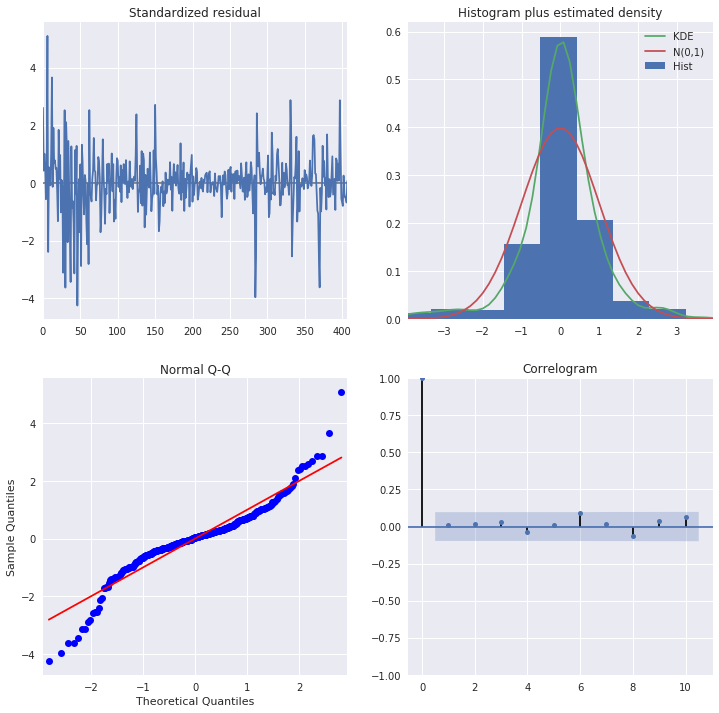

```python
# Summarize residual errors for the automated grid search ARIMA model
print(autogrid_results.summary())
autogrid_results.plot_diagnostics(figsize=(12,12))
plt.show()
```

```python
if notifyStatus: status_notify("ARIMA automated grid search completed! "+datetime.now().strftime('%a %B %d, %Y %I:%M:%S %p'))
```

```python
# # Set up the function to handle the ARIMA calculation
# def Calculate_ARIMA(ns_order, ss_order):
#     startTimeModel = datetime.now()
#     aic_score, bic_score = float("inf"), float("inf")
#     if (verbose): print('Trying to fit the model with parameters:', ns_order, ss_order)
#     try:
#         if (ss_order[3] == 0): grid_model = SARIMAX(train_ts, order=ns_order)
#         else: grid_model = SARIMAX(train_ts, order=ns_order, seasonal_order=ss_order)
#         with warnings.catch_warnings():
#             warnings.simplefilter("ignore")
#             grid_results = grid_model.fit(disp = False)
#         aic_score = grid_results.aic
#         bic_score = grid_results.bic
#         if (verbose): print('Fit ARIMA: order=%s seasonal_order=%s; AIC=%.3f, BIC=%.3f, Fit time=%s' %
#               (ns_order, ss_order, aic_score, bic_score, (datetime.now() - startTimeModel)))
#         return(aic_score, bic_score)
#     except:
#         return(float("inf"), float("inf"))
```

```python
# # Do a manual grid search of ARIMA parameters
# best_score, best_ns_cfg, best_ss_cfg = float("inf"), None, None
# for p in range(start_p, max_p+1):
#     for d in range(start_d, max_d+1):
#         for q in range(start_q, max_q+1):
#             for P in range(start_P, max_P+1):
#                 for D in range(start_D, max_D+1):
#                     for Q in range(start_Q, max_Q+1):
#                         ns_order = (p, d, q)
#                         ss_order = (P, D, Q, seasonal_freq)
#                         aic_score, bic_score = Calculate_ARIMA(ns_order, ss_order)
#                         if (aic_score < best_score):
#                             best_ns_cfg, best_ss_cfg, best_score = ns_order, ss_order, aic_score
#                             print('A better model found: order=%s seasonal_order=%s; AIC=%.3f, BIC=%.3f' % (ns_order, ss_order, aic_score, bic_score))
# print('Best ARIMA model via manual search: order=%s seasonal_order=%s; AIC=%f' % (best_ns_cfg, best_ss_cfg, best_score))
```

```python
# # Summarize residual errors for the manual ARIMA model
# manual_model = SARIMAX(train_ts, order=best_ns_cfg, seasonal_order=best_ss_cfg)
# manual_results = manual_model.fit(disp = False)
# print(manual_results.summary())
# manual_results.plot_diagnostics(figsize=(12,12))
# plt.show()
```

```python
if notifyStatus: status_notify("ARIMA Hyperparameters Search completed! "+datetime.now().strftime('%a %B %d, %Y %I:%M:%S %p'))
```

### 4.c) Evaluate the Residual Errors

A good final check of a model is to review residual forecast errors. Ideally, the distribution of residual errors should be a Gaussian with a zero mean.

```python
# Set the ARIMA order parameters for validation and forecasting
final_ns_order = stepwise_results.order
# final_ns_order = randgrid_results.order
# final_ns_order = autogrid_results.order
# final_ns_order = best_ns_cfg
if seasonal_freq != 0:
    final_ss_order = stepwise_results.seasonal_order
#     final_ss_order = randgrid_results.seasonal_order
#     final_ss_order = autogrid_results.seasonal_order
#     final_ss_order = best_ss_cfg
    print("Final Non-season order:", final_ns_order, 'Final Seasonal Order:', final_ss_order)
else:
    print("Final Non-season order:", final_ns_order)
```

```
Final Non-season order: (4, 1, 2)
```

```
                               SARIMAX Results
==============================================================================
Dep. Variable:                  value   No. Observations:                  512
Model:               SARIMAX(4, 1, 2)   Log Likelihood                -259.352
Date:                Sun, 25 Oct 2020   AIC                            532.704
Time:                        19:38:35   BIC                            562.359
Sample:                    01-01-1978   HQIC                           544.330
                         - 08-01-2020
Covariance Type:                  opg
==============================================================================
                 coef    std err          z      P>|z|      [0.025      0.975]
------------------------------------------------------------------------------
ar.L1          1.2037      0.065     18.466      0.000       1.076       1.332
ar.L2         -0.5007      0.066     -7.622      0.000      -0.629      -0.372
ar.L3         -0.0995      0.059     -1.688      0.091      -0.215       0.016
ar.L4         -0.1526      0.040     -3.835      0.000      -0.231      -0.075
ma.L1         -1.4975      0.061    -24.392      0.000      -1.618      -1.377
ma.L2          0.8496      0.058     14.672      0.000       0.736       0.963
sigma2         0.1614      0.006     28.730      0.000       0.150       0.172
===================================================================================
Ljung-Box (Q):                       54.31   Jarque-Bera (JB):               676.75
Prob(Q):                              0.07   Prob(JB):                         0.00
Heteroskedasticity (H):               0.31   Skew:                            -0.25
Prob(H) (two-sided):                  0.00   Kurtosis:                         8.62
===================================================================================

Warnings:
[1] Covariance matrix calculated using the outer product of gradients (complex-step).
```

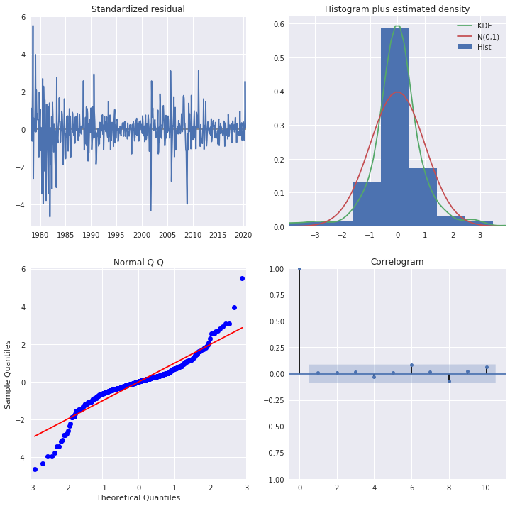

```python
# Summarize residual errors for the final ARIMA model
if seasonal_freq != 0:
    final_model = SARIMAX(time_series, order=final_ns_order, seasonal_order=final_ss_order)
else:
    final_model = SARIMAX(time_series, order=final_ns_order)
final_results = final_model.fit(disp = False)
print(final_results.summary())
final_results.plot_diagnostics(figsize=(12,12))
plt.show()
```

```python
if notifyStatus: status_notify("ARIMA Task 4: Fit and Evaluate Models completed! "+datetime.now().strftime('%a %B %d, %Y %I:%M:%S %p'))
```

## Section 5. Finalize Model and Make Predictions

```python
if notifyStatus: status_notify("ARIMA Task 5: Finalize Model and Make Predictions has begun! "+datetime.now().strftime('%a %B %d, %Y %I:%M:%S %p'))
```

### 5.a) Validation via In-sample Data

```python
validate_forecast = final_results.get_prediction(start = -test_size)
mean_validate_forecast = validate_forecast.predicted_mean
validate_confidence_intervals = validate_forecast.conf_int()
```

```python
# Occasionally some predicted values turned out to be < 0 but they should not be (e.g. rainfall, disease cases, etc.)
# If we have those values, we will need to set them to 0
# print(mean_validate_forecast[mean_validate_forecast < 0])
# mean_validate_forecast[mean_validate_forecast < 0] = 0
```

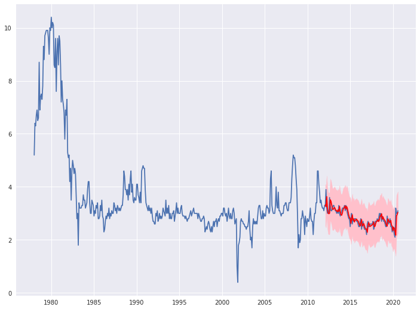

```python
plt.figure(figsize=(12,9))
plt.plot(time_series.index, time_series[target_col], label='observed')
plt.plot(mean_validate_forecast.index, mean_validate_forecast.values, color='red', label='forecast')
plt.fill_between(validate_confidence_intervals.index, validate_confidence_intervals[lower_bound],
                 validate_confidence_intervals[upper_bound], color='pink')
plt.show()
```

```python
# Evaluate RMSE for the validation data
y_test = time_series[-test_size:]
predictions = mean_validate_forecast.values
for i in range(y_test.shape[0]):
    print(y_test.index[i], ' | ', y_test.iloc[i,0], ' | ', predictions[i])
print('RMSE from the validation data is: %.3f' % math.sqrt(mean_squared_error(y_test, predictions)))
```

```
2012-02-01 00:00:00  |  3.3  |  3.31752204416848
2012-03-01 00:00:00  |  3.9  |  3.2519754083242867
2012-04-01 00:00:00  |  3.2  |  3.6322948616376594
2012-05-01 00:00:00  |  3.0  |  3.2243905257176833
2012-06-01 00:00:00  |  3.1  |  3.018782375225768
2012-07-01 00:00:00  |  3.0  |  2.9863066979710515
2012-08-01 00:00:00  |  3.6  |  3.0047844190363495
2012-09-01 00:00:00  |  3.3  |  3.513177855364516
2012-10-01 00:00:00  |  3.1  |  3.4580991886757646
2012-11-01 00:00:00  |  3.1  |  3.320168565102284
2012-12-01 00:00:00  |  3.2  |  3.163868849628989
2013-01-01 00:00:00  |  3.3  |  3.1448887656789952
2013-02-01 00:00:00  |  3.3  |  3.1992449814011223
2013-03-01 00:00:00  |  3.2  |  3.220886475303888
2013-04-01 00:00:00  |  3.1  |  3.1712971001464645
2013-05-01 00:00:00  |  3.1  |  3.103455496007084
2013-06-01 00:00:00  |  3.0  |  3.104615914636936
2013-07-01 00:00:00  |  3.1  |  3.0585642474045622
2013-08-01 00:00:00  |  3.0  |  3.1347699332362122
2013-09-01 00:00:00  |  3.3  |  3.0765308192288496
2013-10-01 00:00:00  |  3.0  |  3.267352252556165
2013-11-01 00:00:00  |  2.9  |  3.0735873805652796
2013-12-01 00:00:00  |  3.0  |  2.9480497888803647
2014-01-01 00:00:00  |  3.1  |  2.92922221334951
2014-02-01 00:00:00  |  3.2  |  3.0144344168799737
2014-03-01 00:00:00  |  3.2  |  3.142828007734618
2014-04-01 00:00:00  |  3.2  |  3.1967660661082484
2014-05-01 00:00:00  |  3.3  |  3.2185217502374006
2014-06-01 00:00:00  |  3.1  |  3.2858450625594755
2014-07-01 00:00:00  |  3.3  |  3.15671499177723
2014-08-01 00:00:00  |  3.2  |  3.2584672777451593
2014-09-01 00:00:00  |  3.0  |  3.1934174372449657
2014-10-01 00:00:00  |  2.9  |  3.0599177802407196
2014-11-01 00:00:00  |  2.8  |  2.934335508310314
2014-12-01 00:00:00  |  2.8  |  2.830152695579617
2015-01-01 00:00:00  |  2.5  |  2.8215601252275992
2015-02-01 00:00:00  |  2.8  |  2.620010987422294
2015-03-01 00:00:00  |  3.0  |  2.7838488342545387
2015-04-01 00:00:00  |  2.6  |  2.9496204754182433
2015-05-01 00:00:00  |  2.8  |  2.741516062984079
```

[output cut: 49 more lines]

```
2019-07-01 00:00:00  |  2.6  |  2.736890284983104
2019-08-01 00:00:00  |  2.7  |  2.66655897615995
2019-09-01 00:00:00  |  2.8  |  2.6629087840092445
2019-10-01 00:00:00  |  2.5  |  2.7338931408361518
2019-11-01 00:00:00  |  2.5  |  2.560856967477329
2019-12-01 00:00:00  |  2.3  |  2.5174090427012303
2020-01-01 00:00:00  |  2.5  |  2.3477031044817283
2020-02-01 00:00:00  |  2.4  |  2.473887973395671
2020-03-01 00:00:00  |  2.2  |  2.4394288251646477
2020-04-01 00:00:00  |  2.1  |  2.3157190714466775
2020-05-01 00:00:00  |  3.2  |  2.1788067566258906
2020-06-01 00:00:00  |  3.0  |  2.8968090081334488
2020-07-01 00:00:00  |  3.0  |  2.9620677861156115
2020-08-01 00:00:00  |  3.1  |  3.036836625039117
RMSE from the validation data is: 0.206
```

### 5.b) Forecasting Out-of-Sample Data

```python
if seasonal_freq != 0:
    forecast_size = seasonal_freq
else:
    forecast_size = int(test_size/2)
final_forecast = final_results.get_forecast(steps = forecast_size)
mean_final_forecast = final_forecast.predicted_mean
final_confidence_intervals = final_forecast.conf_int()
print("The forecasted values are:\n\n", mean_final_forecast)
```

```
The forecasted values are:

 2020-09-01    3.010031
2020-10-01    2.935852
2020-11-01    2.881656
2020-12-01    2.847247
2021-01-01    2.854074
2021-02-01    2.896232
2021-03-01    2.955256
2021-04-01    3.009770
2021-05-01    3.040603
2021-06-01    3.038118
2021-07-01    3.005257
2021-08-01    2.955558
2021-09-01    2.907727
2021-10-01    2.878683
2021-11-01    2.877630
2021-12-01    2.903246
2022-01-01    2.944799
2022-02-01    2.986530
2022-03-01    3.013570
2022-04-01    3.017183
2022-05-01    2.997499
2022-06-01    2.962938
2022-07-01    2.926703
2022-08-01    2.901798
2022-09-01    2.896402
2022-10-01    2.911256
2022-11-01    2.939846
2022-12-01    2.971162
2023-01-01    2.993889
2023-02-01    3.000457
2023-03-01    2.989504
2023-04-01    2.965991
2023-05-01    2.939050
2023-06-01    2.918479
2023-07-01    2.911216
2023-08-01    2.919043
2023-09-01    2.938258
2023-10-01    2.961332
2023-11-01    2.979816
2023-12-01    2.987407
2024-01-01    2.982063
2024-02-01    2.966467
2024-03-01    2.946795
2024-04-01    2.930295
2024-05-01    2.922651
2024-06-01    2.926048
2024-07-01    2.938608
2024-08-01    2.955304
2024-09-01    2.969943
2024-10-01    2.977437
2024-11-01    2.975550
Freq: MS, dtype: float64
```

```python
# Occasionally some predicted values turned out to be < 0 but they should not be (e.g. rainfall, disease cases, etc.)
# If we have those values, we will need to set them to 0
# print(mean_final_forecast[mean_final_forecast < 0])
# mean_final_forecast[mean_final_forecast < 0] = 0
```

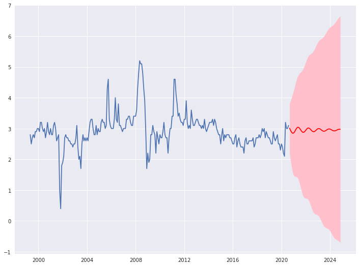

```python
plt.figure(figsize=(12,9))
halfway_point = int(time_series.index.size / 2)
plt.plot(time_series.index[halfway_point:], time_series[target_col][halfway_point:], label='observed')
plt.plot(mean_final_forecast.index, mean_final_forecast.values, color='red', label='forecast')
plt.fill_between(final_confidence_intervals.index, final_confidence_intervals[lower_bound],
                 final_confidence_intervals[upper_bound], color='pink')
plt.show()
```

```python
if notifyStatus: status_notify("ARIMA Task 5: Finalize Model and Make Predictions completed! "+datetime.now().strftime('%a %B %d, %Y %I:%M:%S %p'))
```

```python
print ('Total time for the script:',(datetime.now() - startTimeScript))
```

```
Total time for the script: 0:02:20.499194
```